# Modelado - regresión

Paul Esker

## Antecedentes

En el ejemplo de *regresión múltiple* se vio que el modelo final podía haber sido uno de dos (tal vez, 3) opciones. Bajo el concepto de modelado de vez en cuando nos interesaría estudiar el comportamiento de una relación entre la variable dependiente $Y$ y las variables dependientes, es decir, los posibles diferentes factors, $X_i$. En este sentido los que se consideran son una gran gama de diferentes modelos y la gran pregunta es, “¿Cuál es la mejor manera, así como el mejor enfoque para modelar las posibles relaciones?”

Por lo tanto en este ejercicio vamos a explorar algunos de los métodos diferentes que existen para realizar selección de modelo.

```r
library(tidyverse)
library(Hmisc)
```

```r
library(corrplot)
library(readr)
library(HH)
library(car)
library(scatterplot3d)
library(leaps)
```

## Datos

Para este ejercicio siguimos utilizando los datos de áfidos. Nada ha cambiado en este sentido.

```r
lote <- c(1:34)
afidos <- c(61, 77, 87, 93, 98, 100, 104, 118, 102, 74, 63, 43, 27, 19, 14, 23, 30, 25, 67, 40, 6, 21, 18, 23, 42, 56, 60, 59, 82, 89, 77, 102, 108, 97)
temperatura <- c(21, 24.8, 28.3, 26, 27.5, 27.1, 26.8, 29, 28.3, 34, 30.5, 28.3, 30.8, 31, 33.6, 31.8, 31.3, 33.5, 33, 34.5, 34.3, 34.3, 33, 26.5, 32, 27.3, 27.8, 25.8, 25, 18.5, 26, 19, 18, 16.3)
humedad <- c(57,48, 41.5, 56, 58, 31, 36.5, 41, 40, 25, 34, 13, 37, 19, 20, 17, 21, 18.5, 24.5, 16, 6, 26, 21, 26, 28, 24.5, 39, 29, 41, 53.5, 51, 48, 70, 79.5)

afidos_base <- data.frame(lote, afidos, temperatura, humedad)
```

## Modelo básico

Vamos a empezar con el siguiente modelo:

$$áfidos = intercepto + temperatura + humedad + error$$

Aunque se acabó el otro ejercicio considerando que el modelo con la interacción de los dos factores independientes fue un poco mejor, en esta situación vamos a considerar el modelo aditivo como la base de referencia porque todavía no estamos cien porciento claro que es “la interacción”. También hay interés determinar si los dos factores juntos expliquen bien el desarrollo de los áfidos.

```r
modelo_a <- with(afidos_base, lm(afidos ~ temperatura + humedad))
anova(modelo_a) # ambos factores = significativos
```

|  | Df | Sum Sq | Mean Sq | F value | Pr(>F) |
| --- | --- | --- | --- | --- | --- |
| temperatura | 1 | 15194.799 | 15194.7987 | 28.776477 | 7.553738e-06 |
| humedad | 1 | 4813.054 | 4813.0542 | 9.115141 | 5.038124e-03 |
| Residuals | 31 | 16368.882 | 528.0285 | NA | NA |

```r
summary(modelo_a) #R^2 = 0.55
```

```
##
## Call:
## lm(formula = afidos ~ temperatura + humedad)
##
## Residuals:
##     Min      1Q  Median      3Q     Max
## -35.393 -14.006  -3.198  10.335  49.265
##
## Coefficients:
##             Estimate Std. Error t value Pr(>|t|)
## (Intercept)  35.8255    53.5388   0.669  0.50835
## temperatura  -0.6765     1.4360  -0.471  0.64089
## humedad       1.2811     0.4243   3.019  0.00504 **
## ---
## Signif. codes:  0 '***' 0.001 '**' 0.01 '*' 0.05 '.' 0.1 ' ' 1
##
## Residual standard error: 22.98 on 31 degrees of freedom
## Multiple R-squared:   0.55,  Adjusted R-squared:  0.521
## F-statistic: 18.95 on 2 and 31 DF,  p-value: 4.212e-06
```

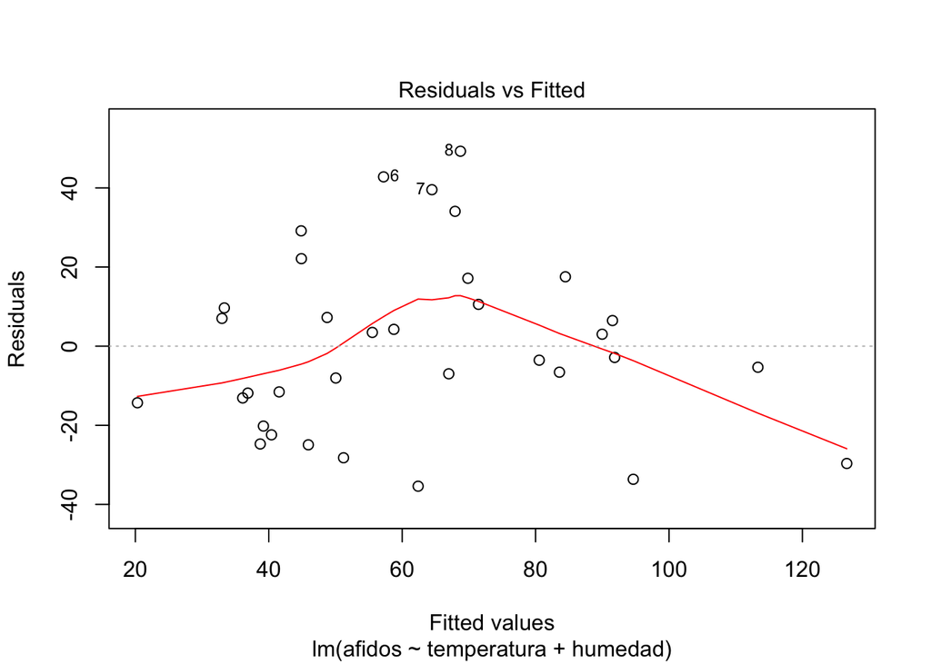

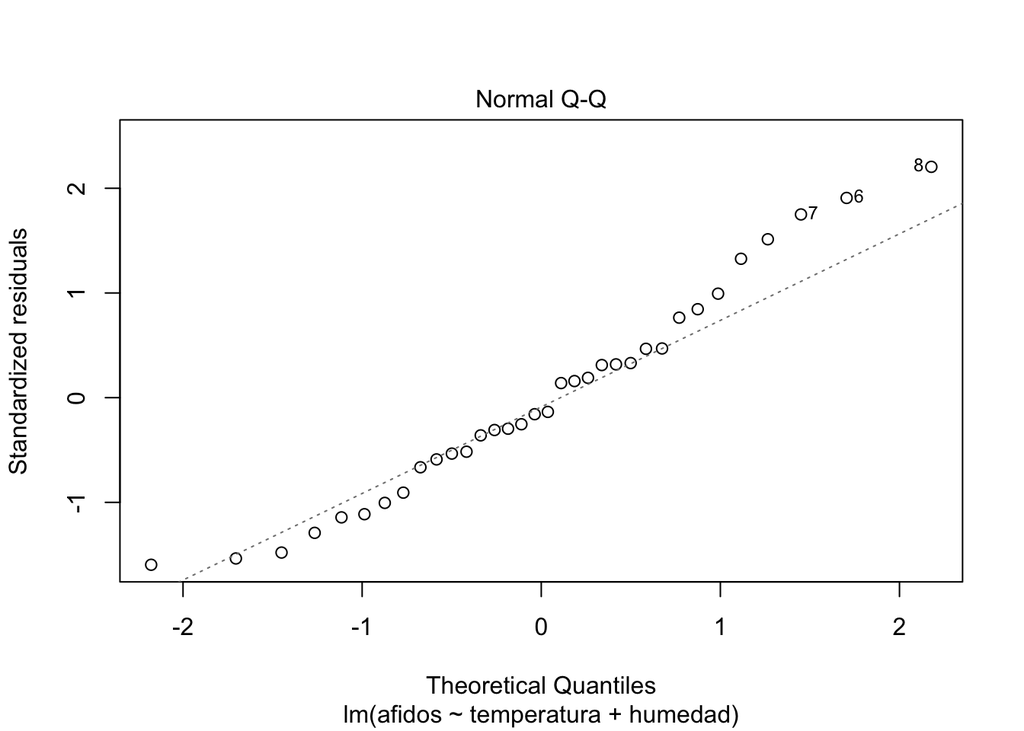

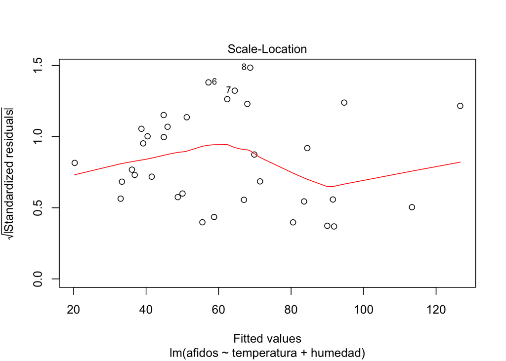

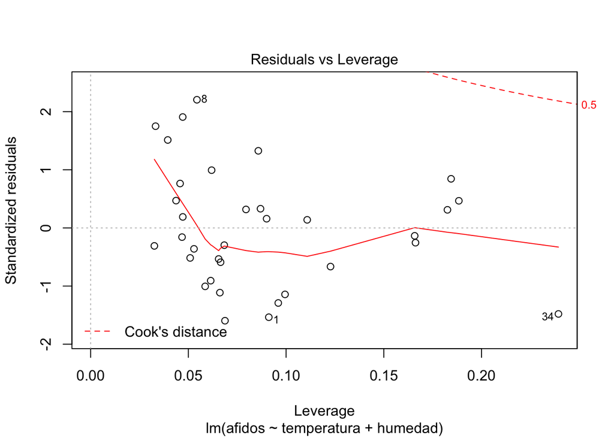

```r
plot(modelo_a)
```

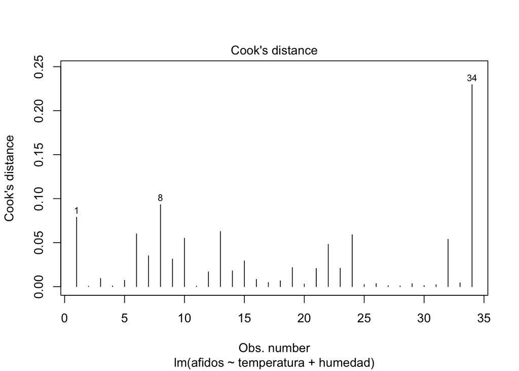

```r
plot(modelo_a, which=4)
```

## Modelo más complejo

Bueno en el ejercicio de *regresión múltiple* nos dimos cuenta que todavía no se había considerado que hubiese otros modelos que podrían ser útiles para explorar las relaciones.

Entonces para poder definir y comparar más modelos ahora lo que vamos a definir es primero el modelo más complejo (sin darse cuenta que posiblemente hubiese otras formas definir la relación, por ejemplo, por un modelo no lineal).

Modelo B: $áfidos = intercepto + temperatura + humedad + temperatura^2 + humedad^2 + temperatura:humedad$

Este modelo asume que los efectos de la temperatura y de la humadad tienen formas que no son exactamente lineales (volver a verse los gráficos en el ejercicio de regresión múltiple). Por lo tanto el modelo cuenta con cada uno de los efectos independientes, las formas respetivas cuadráticas (con base en el uso de una función de indicador, $I$) y la interacción entre los dos factores.

```r
modelo_b <- with(afidos_base, lm(afidos ~ temperatura + humedad + I(temperatura^2) + I(humedad^2) + temperatura:humedad))
anova(modelo_b) # factores significativos: temperatura, humedad, I(temperatura^2)
```

|  | Df | Sum Sq | Mean Sq | F value | Pr(>F) |
| --- | --- | --- | --- | --- | --- |
| temperatura | 1 | 15194.79874 | 15194.79874 | 31.4527178 | 5.277766e-06 |
| humedad | 1 | 4813.05416 | 4813.05416 | 9.9628588 | 3.801373e-03 |
| I(temperatura^2) | 1 | 1982.42634 | 1982.42634 | 4.1035552 | 5.241848e-02 |
| I(humedad^2) | 1 | 805.11043 | 805.11043 | 1.6665513 | 2.072786e-01 |
| temperatura:humedad | 1 | 54.55383 | 54.55383 | 0.1129246 | 7.393441e-01 |
| Residuals | 28 | 13526.79180 | 483.09971 | NA | NA |

```r
summary(modelo_b) #R^2 = 0.63
```

```
##
## Call:
## lm(formula = afidos ~ temperatura + humedad + I(temperatura^2) +
##     I(humedad^2) + temperatura:humedad)
##
## Residuals:
##     Min      1Q  Median      3Q     Max
## -41.700 -12.220  -1.462  10.894  41.673
##
## Coefficients:
##                       Estimate Std. Error t value Pr(>|t|)
## (Intercept)         143.069144 610.542500   0.234    0.816
## temperatura          -5.639044  33.900957  -0.166    0.869
## humedad              -0.182206   8.875236  -0.021    0.984
## I(temperatura^2)      0.029174   0.476345   0.061    0.952
## I(humedad^2)         -0.008121   0.036214  -0.224    0.824
## temperatura:humedad   0.078534   0.233701   0.336    0.739
##
## Residual standard error: 21.98 on 28 degrees of freedom
## Multiple R-squared:  0.6281, Adjusted R-squared:  0.5617
## F-statistic:  9.46 on 5 and 28 DF,  p-value: 2.285e-05
```

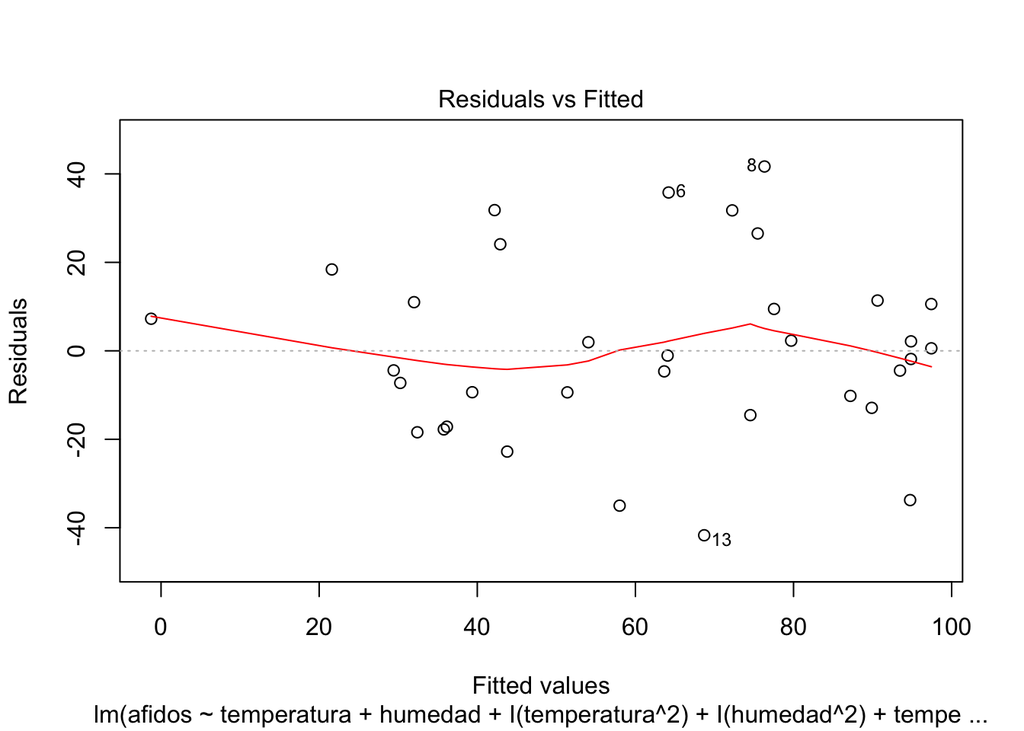

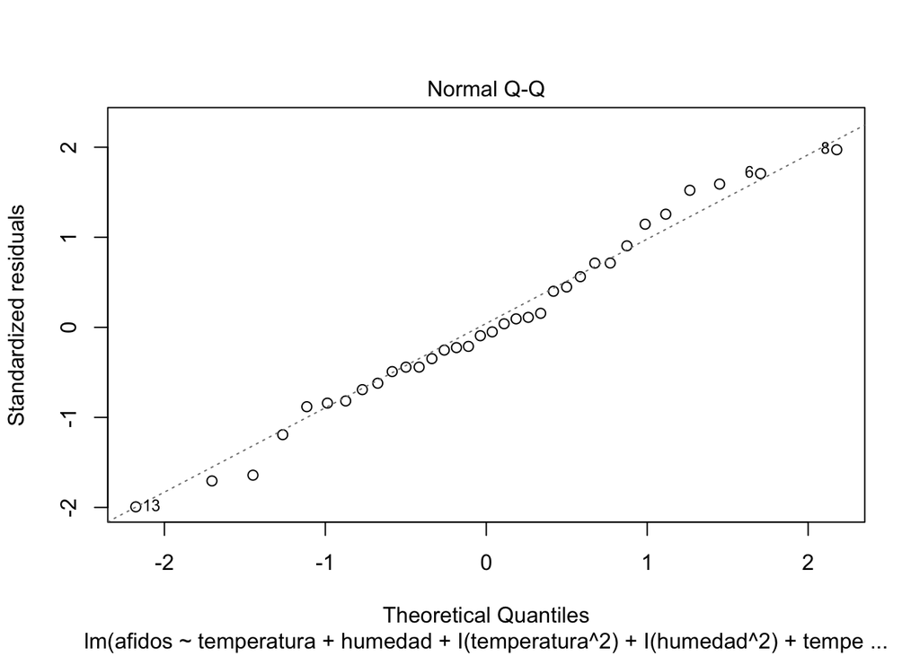

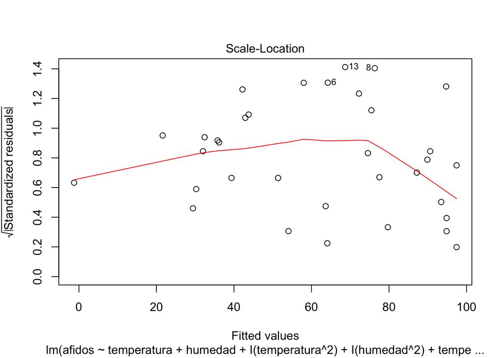

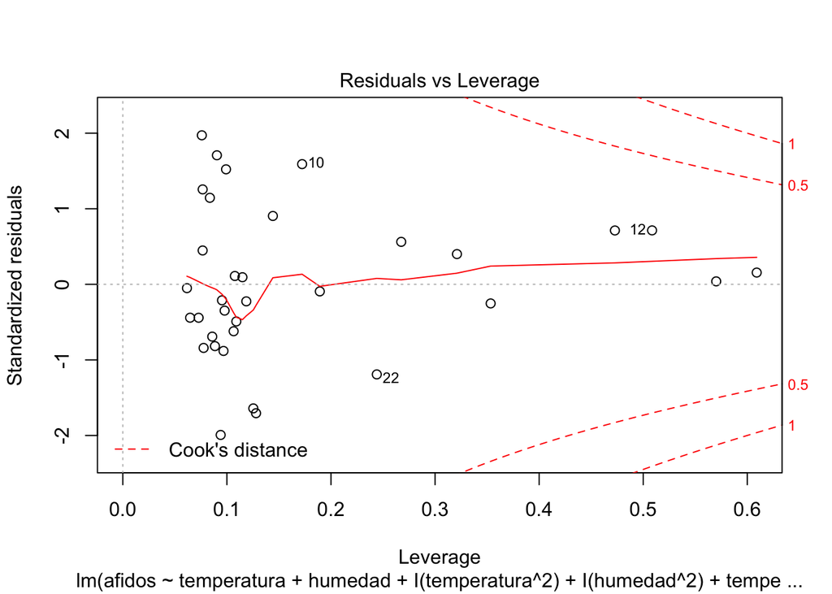

```r
plot(modelo_b)
```

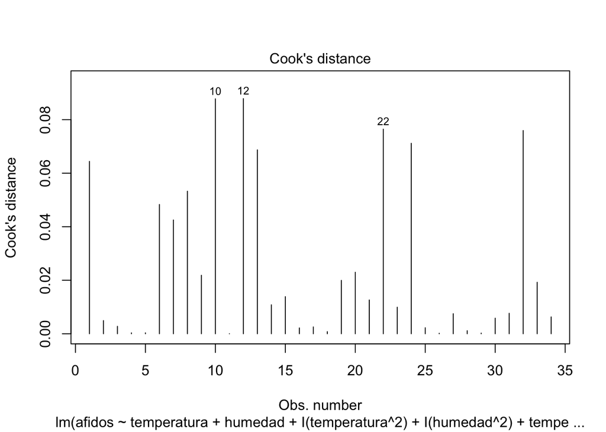

```r
plot(modelo_b, which=4)
```

## Comparación de los primeros dos modelos

```r
anova(modelo_a, modelo_b) #Resulta es que el modelo más complejo no se mejoró lo de la relación, es decir que probablemente es un modelo sobre ajustado
```

|  | Res.Df | RSS | Df | Sum of Sq | F | Pr(>F) |
| --- | --- | --- | --- | --- | --- | --- |
| 1 | 31 | 16368.88 | NA | NA | NA | NA |
| 2 | 28 | 13526.79 | 3 | 2842.091 | 1.96101 | 0.142743 |

## Modelado: tres métodos bajo consideración

Ahora vamos a examinar algunos de los métodos que existen para realizar una comparación de modelos de manera más automática. La idea en esta parte del ejercicio es minimizar la necesidad de redactar muchos modelos y duplicar lo mismo en cada paso. Esto significa que lo más importante es determinar dentro de las factores en estudio cuales sean más importantes y de ahí se puede estudiar el comportamiento del modelo para poder explicar la variable dependiente.

Los tres métodos que se usan en esta sección: * Método manual * Método por pasos (“steps”) * Método por mejores subconjuntos (“best subsets”)

```r
# Construcción del modelo de manera manual
# Primero vamos a considerar el modelo b

# El proceso será reducir el modelo factor por factor, revisando el cambio en el ajuste del modelo (es decir, el signficado)


# Eliminar el factor de: Temperatura:Humedad
modelo_b2 <- update(modelo_b, .~.-temperatura:humedad)
summary(modelo_b2)
```

```
##
## Call:
## lm(formula = afidos ~ temperatura + humedad + I(temperatura^2) +
##     I(humedad^2))
##
## Residuals:
##     Min      1Q  Median      3Q     Max
## -40.969 -12.837  -1.096  12.670  41.617
##
## Coefficients:
##                   Estimate Std. Error t value Pr(>|t|)
## (Intercept)      -57.45005  127.24411  -0.451   0.6550
## temperatura        5.24487    9.85861   0.532   0.5988
## humedad            2.77322    1.17389   2.362   0.0251 *
## I(temperatura^2)  -0.11851    0.18088  -0.655   0.5175
## I(humedad^2)      -0.01921    0.01465  -1.311   0.2001
## ---
## Signif. codes:  0 '***' 0.001 '**' 0.01 '*' 0.05 '.' 0.1 ' ' 1
##
## Residual standard error: 21.64 on 29 degrees of freedom
## Multiple R-squared:  0.6266, Adjusted R-squared:  0.5752
## F-statistic: 12.17 on 4 and 29 DF,  p-value: 6.302e-06
```

```r
anova(modelo_b, modelo_b2) ## resulta es que el factor temperatura:humedad = no significativo
```

|  | Res.Df | RSS | Df | Sum of Sq | F | Pr(>F) |
| --- | --- | --- | --- | --- | --- | --- |
| 1 | 28 | 13526.79 | NA | NA | NA | NA |
| 2 | 29 | 13581.35 | -1 | -54.55383 | 0.1129246 | 0.7393441 |

```r
# Ahora vamos a eliminar el factor I(humedad^2 del modelo b2)
modelo_b3 <- update(modelo_b2, .~.-I(humedad^2))
summary(modelo_b3) # todos los factores parecen tener algo explicativo
```

```
##
## Call:
## lm(formula = afidos ~ temperatura + humedad + I(temperatura^2))
##
## Residuals:
##     Min      1Q  Median      3Q     Max
## -37.782 -13.595  -3.561   9.367  43.291
##
## Coefficients:
##                   Estimate Std. Error t value Pr(>|t|)
## (Intercept)      -152.5753   105.7801  -1.442  0.15955
## temperatura        13.9936     7.3439   1.905  0.06634 .
## humedad             1.3263     0.4050   3.275  0.00267 **
## I(temperatura^2)   -0.2769     0.1362  -2.033  0.05096 .
## ---
## Signif. codes:  0 '***' 0.001 '**' 0.01 '*' 0.05 '.' 0.1 ' ' 1
##
## Residual standard error: 21.9 on 30 degrees of freedom
## Multiple R-squared:  0.6045, Adjusted R-squared:  0.565
## F-statistic: 15.29 on 3 and 30 DF,  p-value: 3.217e-06
```

```r
anova(modelo_b2, modelo_b3) # I(humedad^2) = no significativo
```

|  | Res.Df | RSS | Df | Sum of Sq | F | Pr(>F) |
| --- | --- | --- | --- | --- | --- | --- |
| 1 | 29 | 13581.35 | NA | NA | NA | NA |
| 2 | 30 | 14386.46 | -1 | -805.1104 | 1.719138 | 0.2000916 |

```r
anova(modelo_a, modelo_b3) ## esta alrededor de 0,05 (tiene valor predictivo)
```

|  | Res.Df | RSS | Df | Sum of Sq | F | Pr(>F) |
| --- | --- | --- | --- | --- | --- | --- |
| 1 | 31 | 16368.88 | NA | NA | NA | NA |
| 2 | 30 | 14386.46 | 1 | 1982.426 | 4.133943 | 0.05096144 |

```r
modelo_b4 <- update(modelo_b3, .~.-I(temperatura^2))
anova(modelo_b4)
```

|  | Df | Sum Sq | Mean Sq | F value | Pr(>F) |
| --- | --- | --- | --- | --- | --- |
| temperatura | 1 | 15194.799 | 15194.7987 | 28.776477 | 7.553738e-06 |
| humedad | 1 | 4813.054 | 4813.0542 | 9.115141 | 5.038124e-03 |
| Residuals | 31 | 16368.882 | 528.0285 | NA | NA |

```r
summary(modelo_b4)
```

```
##
## Call:
## lm(formula = afidos ~ temperatura + humedad)
##
## Residuals:
##     Min      1Q  Median      3Q     Max
## -35.393 -14.006  -3.198  10.335  49.265
##
## Coefficients:
##             Estimate Std. Error t value Pr(>|t|)
## (Intercept)  35.8255    53.5388   0.669  0.50835
## temperatura  -0.6765     1.4360  -0.471  0.64089
## humedad       1.2811     0.4243   3.019  0.00504 **
## ---
## Signif. codes:  0 '***' 0.001 '**' 0.01 '*' 0.05 '.' 0.1 ' ' 1
##
## Residual standard error: 22.98 on 31 degrees of freedom
## Multiple R-squared:   0.55,  Adjusted R-squared:  0.521
## F-statistic: 18.95 on 2 and 31 DF,  p-value: 4.212e-06
```

```r
anova(modelo_b3, modelo_b4)
```

|  | Res.Df | RSS | Df | Sum of Sq | F | Pr(>F) |
| --- | --- | --- | --- | --- | --- | --- |
| 1 | 30 | 14386.46 | NA | NA | NA | NA |
| 2 | 31 | 16368.88 | -1 | -1982.426 | 4.133943 | 0.05096144 |

```r
# Se puede continuar eliminando los factores principales pero ya sabemos que cada uno de ellos tiene algo de valor predictivo

# Considerando el resultado, creo que lo mejor sería continuar con el modelo b3
```

## Modelado por pasos automáticos

Ahora vamos a realizar el mismo ejercicio pero por el uso de la función *step()*.

Para hacer esta parte primero necesitamos definir tanto el modelo nulo como el modelo completo (más grande, digamos). De ahí vamos a realizar el proceso utilizando: 1. El método hacía adelante 2. El método hacia atrás 3. El método en ambas direcciones (“ambos sentidos”)

```r
nulo <- lm(afidos~1, data=afidos_base)
completo <- modelo_b

# E
adelante <- step(nulo, scope=list(lower=nulo, upper=completo, direction="forward")) ##hacia adelante
```

```
## Start:  AIC=239.16
## afidos ~ 1
##
##                    Df Sum of Sq   RSS    AIC
## + humedad           1     19891 16486 214.25
## + I(temperatura^2)  1     16098 20279 221.29
## + I(humedad^2)      1     15560 20817 222.18
## + temperatura       1     15195 21182 222.77
## <none>                          36377 239.16
##
## Step:  AIC=214.25
## afidos ~ humedad
##
##                    Df Sum of Sq   RSS    AIC
## + I(humedad^2)      1    2371.2 14115 210.97
## <none>                          16486 214.25
## + I(temperatura^2)  1     358.4 16128 215.51
## + temperatura       1     117.2 16369 216.01
## - humedad           1   19890.7 36377 239.16
##
## Step:  AIC=210.97
## afidos ~ humedad + I(humedad^2)
##
##                    Df Sum of Sq   RSS    AIC
## <none>                          14115 210.97
## + I(temperatura^2)  1     400.9 13714 211.99
## + temperatura       1     332.4 13782 212.16
## - I(humedad^2)      1    2371.2 16486 214.25
## - humedad           1    6702.0 20817 222.18
```

```r
atras <- step(modelo_b) # hacia atrás, por defecto basándose en el modelo inicial
```

```
## Start:  AIC=215.53
## afidos ~ temperatura + humedad + I(temperatura^2) + I(humedad^2) +
##     temperatura:humedad
##
##                       Df Sum of Sq   RSS    AIC
## - I(temperatura^2)     1     1.812 13529 213.53
## - I(humedad^2)         1    24.294 13551 213.59
## - temperatura:humedad  1    54.554 13581 213.66
## <none>                             13527 215.53
##
## Step:  AIC=213.53
## afidos ~ temperatura + humedad + I(humedad^2) + temperatura:humedad
##
##                       Df Sum of Sq   RSS    AIC
## - I(humedad^2)         1    76.241 13605 211.72
## - temperatura:humedad  1   253.787 13782 212.16
## <none>                             13529 213.53
##
## Step:  AIC=211.72
## afidos ~ temperatura + humedad + temperatura:humedad
##
##                       Df Sum of Sq   RSS    AIC
## <none>                             13605 211.72
## - temperatura:humedad  1      2764 16369 216.01
```

```r
step(modelo_b, direction="backward") #hacía atrás
```

```
## Start:  AIC=215.53
## afidos ~ temperatura + humedad + I(temperatura^2) + I(humedad^2) +
##     temperatura:humedad
##
##                       Df Sum of Sq   RSS    AIC
## - I(temperatura^2)     1     1.812 13529 213.53
## - I(humedad^2)         1    24.294 13551 213.59
## - temperatura:humedad  1    54.554 13581 213.66
## <none>                             13527 215.53
##
## Step:  AIC=213.53
## afidos ~ temperatura + humedad + I(humedad^2) + temperatura:humedad
##
##                       Df Sum of Sq   RSS    AIC
## - I(humedad^2)         1    76.241 13605 211.72
## - temperatura:humedad  1   253.787 13782 212.16
## <none>                             13529 213.53
##
## Step:  AIC=211.72
## afidos ~ temperatura + humedad + temperatura:humedad
##
##                       Df Sum of Sq   RSS    AIC
## <none>                             13605 211.72
## - temperatura:humedad  1      2764 16369 216.01
```

```
##
## Call:
## lm(formula = afidos ~ temperatura + humedad + temperatura:humedad)
##
## Coefficients:
##         (Intercept)          temperatura              humedad
##           150.70989             -4.72276             -1.29670
## temperatura:humedad
##             0.09728
```

```r
ambos <- step(modelo_b, direction="both") #en ambas direcciones
```

```
## Start:  AIC=215.53
## afidos ~ temperatura + humedad + I(temperatura^2) + I(humedad^2) +
##     temperatura:humedad
##
##                       Df Sum of Sq   RSS    AIC
## - I(temperatura^2)     1     1.812 13529 213.53
## - I(humedad^2)         1    24.294 13551 213.59
## - temperatura:humedad  1    54.554 13581 213.66
## <none>                             13527 215.53
##
## Step:  AIC=213.53
## afidos ~ temperatura + humedad + I(humedad^2) + temperatura:humedad
##
##                       Df Sum of Sq   RSS    AIC
## - I(humedad^2)         1    76.241 13605 211.72
## - temperatura:humedad  1   253.787 13782 212.16
## <none>                             13529 213.53
## + I(temperatura^2)     1     1.812 13527 215.53
##
## Step:  AIC=211.72
## afidos ~ temperatura + humedad + temperatura:humedad
##
##                       Df Sum of Sq   RSS    AIC
## <none>                             13605 211.72
## + I(humedad^2)         1     76.24 13529 213.53
## + I(temperatura^2)     1     53.76 13551 213.59
## - temperatura:humedad  1   2764.04 16369 216.01
```

## Modelo por mejores subconjuntos

En la última parte del ejercio ahora lo que vamos a crear son modelos considerando los mejores subconjuntos de modelos. En el paquete *leaps* podemos aprovechar la función regsubsets (subconjuntos de regresión) y definir el número de modelos subconjuntos de cada tamaño a considerar. Este método no nos da una respuesta como tal sino lo que sería el mejor modelo. Con esta información ya podemos volver a definir el modelo y estudiar el compartamiento en la relación.

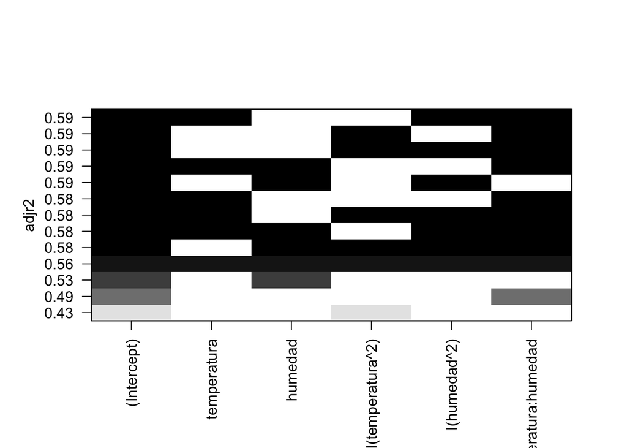

```r
# regsubsets = paquete *leaps*

subconjuntos <- regsubsets(afidos~temperatura+humedad+I(temperatura^2)+
I(humedad^2)+temperatura:humedad, nbest=3, data=afidos_base)

plot(subconjuntos, scale="adjr2")
```

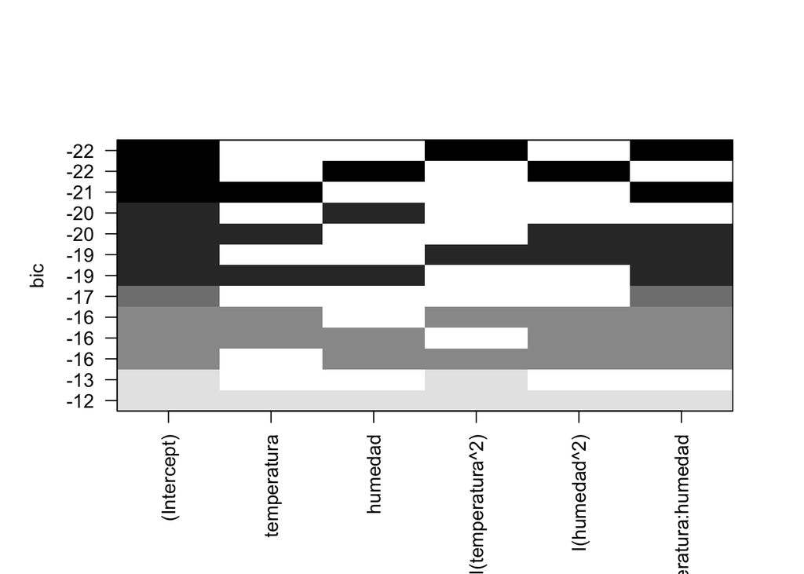

```r
plot(subconjuntos, scale="bic")
```

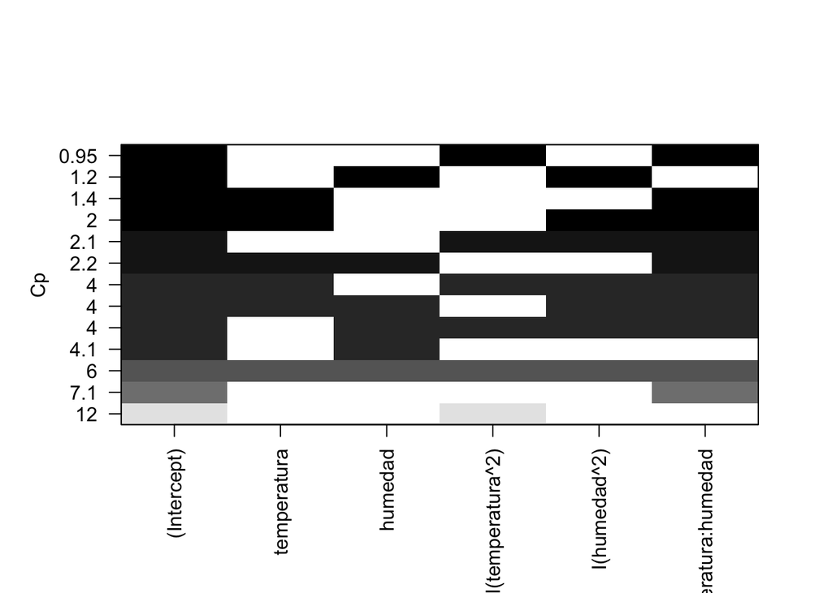

```r
plot(subconjuntos, scale="Cp")
```

## Resumen

Se sabe que el modelado no es actividad fácil. Necesitamos integrar muchos conceptos tantos aquellos matemáticos y estadísticos como los biologícos y agronómicos. También al tener confianza en manejar los modelos es una habilidad importante para poder explicar lo que significa el modelo a un productor, a otra científica, etc.

¿Cuál es el mejor método modelar las relaciones observadas?

Según Gelman y Hall (2007; *Data Analysis Using Regression and Multilevel/Hierarchical Models*):

1. Incluir todas las variables que podrían predecir algo sobre la variable dependiente.
2. No todas las variables predictivas tiene que entrar al modelo de manera individual. Se puede considerar una seríe de variables promediadas o sumadas para crear un “valor combinado” (se ve como índice).
3. Para las variables predictivas con efectos grandes, vale la pena considerarse la inclusión de un término que representa las interacciones entre aquellas variables.
4. Una estrategía para tomar decisiones sobre la inclusión de una variable:
- si el predictor no sea significativo estadísticamente pero tiene la dirección esperada (el signo esperado), por lo general se puede mantener en el modelo debido a que mientras que no se afecta las predicciones tampoco no está ocasionando algún asunto con el modelo.
- si el predictor no sea significativo estadísticamente y no tiene la dirección esperada, se puede considerar la elminación del modelo.
- si el predictor sea significativo estadísticametne pero no tiene la dirección esperada, hay que pensar cuidosamente si este factor tiene sentido. Piénselo en variables de confusión en estos casos (en inglés: confounding variables, lurking variables).
- si el predictor sea significativo estadístamente con la dirección esperada, obviamente hay que mantenerlo en el modelo.

Muy importante es que los métodos mencionados anteriormente no resuelvan todos los asuntos de modelado pero ojalá nos ayuda minimizar los errores que podrían ser cometidos en el análisis e interpretación de datos.